# Writing and running code in R Studio

### The **Environment** pane

We can use the **Environment** pane to see any objects that we’ve created. We’ll explore this now.

But first let’s clear our **Environment** of any objects we’ve already created. Run the command below at the **console**.

```r
rm(list = ls())
```

Once you’ve run this command check out the **Environment** pane. It should now be nice and empty.

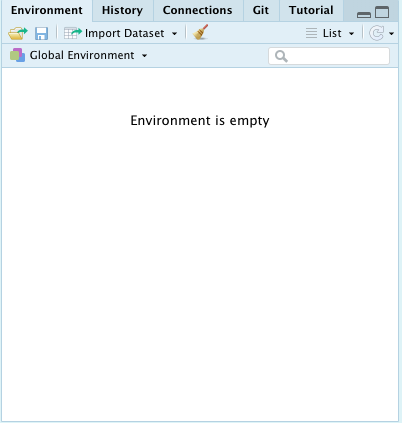

An empty environment pane

Now try running a couple of commands. One where it print something out to the **console**, and one where you assign the output to an **object**. Take a look at the two commands below t get some ideas for commands to run.

```r
7 + 4 / 3

my_name <- "Inigo Montoya"
```

Notice that when the output is printed to **console** you don’t get anything new appearing in your **Environment** pane. But when you assign something to an **object** then you’ll been able to see the **name** of the **object** in the **Environment** pane.

### Writing code in R Markdown (`.Rmd`) files

In this course, then main place we’ll be writing **R** code is not in the **console** but inside `.Rmd` files.

Let’s go ahead and create a new `.Rmd` file. See if you can remember how to do it from last time. Click the hint if you get stuck.

You can create a new `.Rmd` file through the menu.

**File > New File > R Markdown…**

And then just click `OK`

You can just leave all the options at their default values.

Once you have a new `.Rmd` file clear it out so that you only have the YAML header lines and the next few lines below. It should look like the example below.

````
---
title: "Untitled"
output: html_document
---

```{r setup, include=FALSE}
kntir::opts_chunk$set(echo = TRUE)
```
````

You can go ahead and add a title and an author if you want, and then save the file into the `r_docs` sub-folder of your project folder.

In a previous practical you got a chance to write markdown. You made heading and wrote text and made lists.

But you can also write `R` code into `.Rmd` files. To do this, we’ll use something called a **code chunk**. Your document already has one code chunk. It’s called the **setup chunk**. We’ll cover code chunks in general first, and then swing back to the **setup** chunk.

#### Code chunks

Code chunks are marked off in your `.Rmd` file with **fences**. In their basic form they just look like this:

````
```{r}


```
````

They have an opening fence:

````
```{r}
````

And a closing fence:

````
```
````

To insert a code chunk you can just type it directly into the `.Rmd` file.

Just hit `` ` `` `` ` `` `` ` `` `{` `r` `}` `enter` `enter` `` ` `` `` ` `` `` ` ``

If you can’t find the `` ` `` key then it should either be on the top row next to the `1` (on most windows keyboards with a UK layout and US layout Mac keyboards) or on the bottom row next to the `z` (on some UK layout Mac keyboards).

Or you can use the shortcut key of `ctrl` + `alt` + `i` (Windows) or `⌘ cmd` + `⌥ opt` + `i` (MacOS)

Let’s go ahread and add a **code chunk**! Just and the opening and closing fences. You don’t need to anything in between them for now.

So what are code chunks?

Anything inside the **code chunk** is treated as `R` code. You can write code in them but (unlike in the **console**) that code won’t run when you hit `enter`. To run the code you have to **explicitly** run it.

How do you explicitly run the code? There are three ways:

1. You can put the cursor on the line you want to run and hit `ctrl` + `enter` (Windows) or `⌘ cmd` + `enter` (MacOS)
2. You can click on the little green triangle ▶ at the top of the code chunk to run all the code in that chunk
3. Or finally, you can **knit** the document to run **all the code chunks** in the entire document from the top to the bottom. Note that when you **knit** a document with with **code chunks** that have errors then it will usually fail to **knit**. However, when you’re working on `.Rmd` files in these practicals they’ll usually be set up to ignore errors and just print out error messages instead.

Before we can run a code chunk we need to add some code to them.

Let’s add some code into the chunk. Add the following code

```
Sys.sleep(15)
```

Your code chunk should now look like this:

````markdown
```{r}

Sys.sleep(15)

```
````

Once you’ve added some code, run it by either using `ctrl` + `enter` (Windows) or `command` + `enter` (MacOS) or hitting the ▶

When you do this, you’ll see the ▶ turn into a 🕒 and then a 🟥. When it’s shows a 🟥 it means the code is running. Wait for the ▶ to return before continuing.

Now let’s clear out the code chunk again put some other code it in.

Let’s replace the:

```r
Sys.sleep(15)
```

with

```r
cat("hello world")
```

Now run this code chunk… What happens?

The words “hello world” get printed out below the code chunk!

So code chunks can print out output just like when you run code at the console.

Let’s now create another code chunk. Let’s include some code but this time we’ll assign the output to a variable.

Something like this:

````markdown
```{r}

vect2 <- c(1,2,3,4)

```
````

Once you’ve inserted the code chunk, try running the code.

What do you see?

That’s right, just like when you run code at the console assigning the output to object means the output won’t be printed (shown). To show the output we can just add a new line with just the object’s name to show the content of that object.

**Tip** Sometimes your `.Rmd` file might look strange, because the syntax highlight disappears or little ▶ disappears. This happens when you don’t have matching fences or if you’ve put a code chunk inside another code chunk.

If this happens then check over your document and make sure that all your opening fences `` ```{r} `` have matching closing fences `` ``` `` and that you don’t open another fence before closing the previous one.

### The environment and **knitting**

We’ve seen that when we create objects by either typing lines into the **console** or explicitly running lines we’ve written into `.Rmd` files then we can see the objects in the **Environment** pane.

The **Environment** pane is just going to keep track of any of the objects we create in a session and they’ll be available for the entirety of the session.

**However, when you knit a `.Rmd` file something special happens!** When you knit a document all the code in the `.Rmd` file is run **inside a new empty enviroment**. That means that when you **knit** the document, `R` will only have access to **objects created inside the document**. It won’t have access to objects that haven’t been created **inside the document**.

The best way to see what this means is to try a little test.

Go to your `.Rmd` file and empty it completely so that it is totally blank. Once you’ve done this, copy the following code into your document.

````
---
title: "Knit enviroment"
output: html_document
---

```{r setup, include=FALSE}
knitr::opts_chunk$set(echo = TRUE, error = TRUE)
```


```{r}
cat("my name is",name)
```
````

You’ll notice that the highlighted line makes use on a object called `name`

Let’s create a object called name by typing something like the following into the console.

```r
name <- "Spartacus"
```

You’ll now be able to see that you have an object called `name` in your **Environment** pane.

Now let’s go to the `.Rmd` file. Go to the code chunk with the line `cat("my name is ",name)` and click the ▶…

What happens?

That’s right. It prints out `my name is Spartacus`

Now, try and **knit** the `.Rmd` file by using the shortcut key `ctrl` + `shift` + `k` (Windows) or `⌘ cmd` + `shift` + `k` (MacOS) or by clicking the knit icon.

What do you see in the output document? Do you see anything strange or any errors?

You should see a line that looks something like this: `## Error in cat("my name is", name): object name not found`

Why has this happened?

This has happened because the object `name` was not created anywhere inside that `.Rmd` file. We created it at the console. When you knit the document it gets knitted inside its own environment that only contains the objects created in that `.Rmd` file.

Do you know how to fix it?

You can fix it by creating the `name` object inside the `.Rmd` file. Try editing the code in that code chunk so that it now reads like the following.

```
name <- "Spartacus"
cat("my name is",name)
```

### The `setup` chunk

You’d have noticed that right at the top of you document there is already a code chunk. This chunk is called the **setup** chunk, and it has some extra stuff in the opening fence. It’s highlighted below.

````r
```{r setup, include=FALSE}
knitr::opts_chunk$set(echo = TRUE)
```
````

For now, you don’t need to worry about this extra stuff. You’ll learn more about what this means next year.

What makes the setup chunk special is that any code **inside** the setup chunk is automatically run before any of the other code is run. This is the case whether we **knit** the document or just explicitly run any of the other code chunks.

We haven’t covered packages yet, but we’ll usually be using the setup code chunk to load any packages.

### Writing code in **R** script (`.R`) files

In this course, we won’t really be using `.R` script files at all. But we can play around with one now if you’d like to see what they’re all about.

Writing `R` code into the **Console** window is fine for one off commands or for testing things. In fact, it’s very useful for this and you should make use of it for this.

However, there’s often times where we want to **write down** a bunch of commands first and then **run them later**. There are two places we can do this. The first is in `.R` script files.

Let’s go ahead and create a new script file. You can do this through the menu by going to **File** > **New File** > **R Script** or you can use the keyboard shortcuts. Try using `ctrl` + `shift` + `n` (Windows) or `⌘ cmd` + `shift` + `n` (MacOS).

`.R` script files allows you to write code but this code doesn’t run until you **explicitly** tell `R` to run it.

Let’s take some code and first we’ll paste it into the **Console** window.

```r
this_class <- 'Psychology as a Science'
cat(this_class,'is great')
```

When you hit enter you should see something like this…

```
## Psychology as a Science is great
```

After you’ve pasted the code into the **Console** it runs as soon as you hit `enter`.

Now let’s take that exact same code and paste it into the new `.R` file we’ve created.

After you hit `enter` nothing happens?!

To make it run you have to **explicitly** tell `R` to run it. To do this you put your cursor on the line that you want to run and you hit `ctrl` + `enter` (Windows) or `⌘ cmd` + `enter` (MacOS).

Watch the **Console** as you run each line and you’ll see that it runs. Code written in a `.R` file is just there doing nothing until you run it. If you make changes then you have to re-run it if you want to see the result of those changes.

## Test your understanding

[interactive chart not shown]